# Atividade Final - Ciência Colaborativa

Gustavo Viana de Freitas - PPGERN UENF

22 outubro, 2021

# 1 Atividade final - Ferramentas em ciência colaborativa e bancos de dados abertos

## 1.1 Contexto

A atividade final consistiu em alimentar um repositório criado durante o período da disciplina (20-09-2021 a 24-09-2021), com atividades realizadas em aula e posteriormente. Além disso, consistiu na criação de um novo repositório, a parte dos que foram criados durante as aulas e criar uma página github com outro banco de dados, de autoria própria ou disponíveis em plataformas de banco de dados. Os roteiros mais detalhados da disciplina podem ser vistos no [Repositório da Disciplina](https://cammcordeiro.github.io/ciencia_colab/index.html).

Link do novo repositório criado [GustavoVianadeFreitas](https://github.com/GustavoVianadeFreitas/Gustavo_ciencia_colab)

As atividades 4 e 5 foram reproduzidas novamente com dados próprios no intuito de alimetar o novo repositório criado. Os dados se referem a uma atividade de campo que buscou relacionar a abundância de líquens crostosos em uma região de floresta ombrófila da Floresta Atlântica em duas condições de superfície arbórea (superfície lisa e rugosa) e microclimática (borda e interior florestal). O objetivo da coleta desses dados foi verificar a influência das condições microclimátias e da superfície arbórea na abundância desses líquens. A hipótese era de que troncos não rugosos e condições de borda permitirão maior abundância de morfotipos crostosos, devido sua forte aderência ao substrato e ausência de córtex, tendo preferência por ambienteis mais estressantes como a borda florestal.

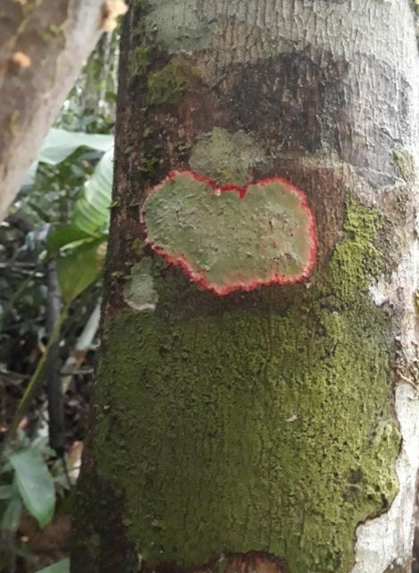

## 1.2 Análises Estatísticas e Discussão

1. Primeiramente, os dados foram importados para observação

```r
liquens<-read.table("liquenes.txt", h=T)
head(liquens)
```

```
##   crostoso substrato condicao
## 1       34 naorugoso    borda
## 2       67 naorugoso    borda
## 3       23 naorugoso    borda
## 4       25 naorugoso    borda
## 5       39 naorugoso    borda
## 6       40 naorugoso    borda
```

2. Após o carregamento dos dados, observamos a distribuição das variáveis contínuas

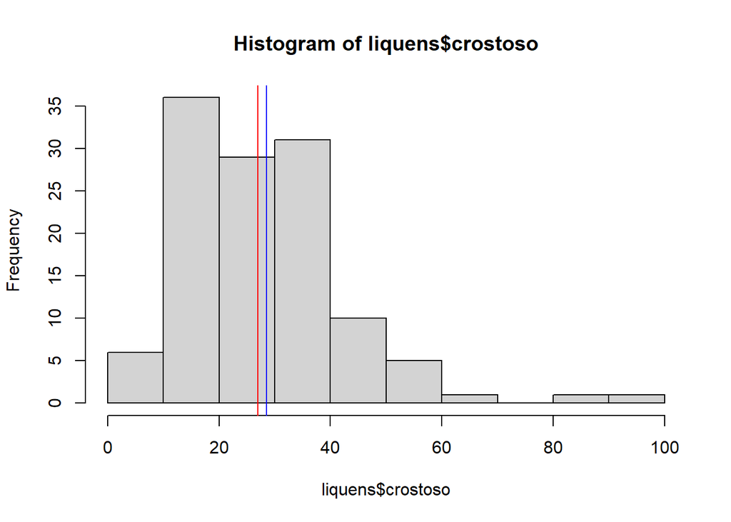

```r
hist(liquens$crostoso)
abline(v=27.00, col="red") #Mediana
abline(v=28.49, col="blue") #Média
```

```r
summary(liquens)
```

```
##     crostoso      substrato           condicao
##  Min.   : 1.00   Length:120         Length:120
##  1st Qu.:18.00   Class :character   Class :character
##  Median :27.00   Mode  :character   Mode  :character
##  Mean   :28.49
##  3rd Qu.:36.00
##  Max.   :91.00
```

```r
### Os dados são assimétricos, mas por questões de facilitar a reprodução das atividades, os dados serão considerados sem transformação.
```

3. Nessa etapa, criamos um modelo de anova two-way

Os dados foram submetidos à uma Análise de Variância two-way (ANOVA two-way), uma vez que a finalidade desse trabalho foi avaliar a abundância de morfotipos crostosos (variável dependente) em duas condições específicas: a superfície dos troncos e a condição microclimática (duas variáveis independentes).

```r
### Testamos se há uma interação das variáveis categóricas com a variável contínua
liquens_ANOVA_twoway<-aov(crostoso~substrato*condicao, data=liquens)
anova(liquens_ANOVA_twoway)
```

```
## Analysis of Variance Table
##
## Response: crostoso
##                     Df  Sum Sq Mean Sq F value   Pr(>F)
## substrato            1  1435.2 1435.21  7.5138 0.007093 **
## condicao             1   444.7  444.68  2.3280 0.129785
## substrato:condicao   1   755.0  755.01  3.9527 0.049151 *
## Residuals          116 22157.1  191.01
## ---
## Signif. codes:  0 '***' 0.001 '**' 0.01 '*' 0.05 '.' 0.1 ' ' 1
```

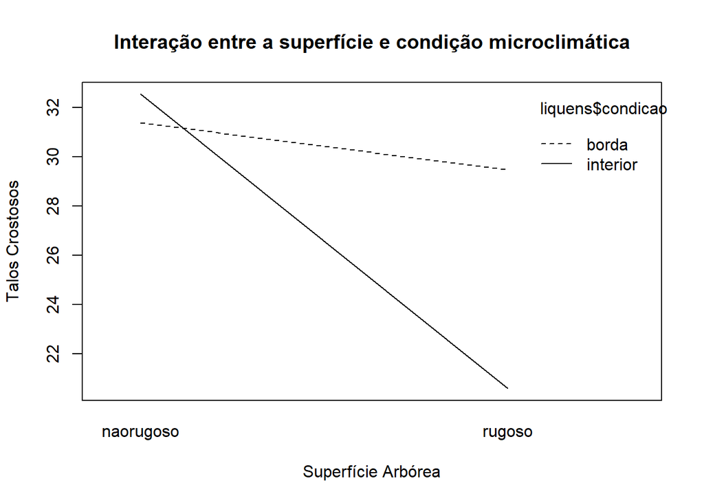

```r
#Aqui, mostrando o gráfico de interação.
interaction.plot(liquens$substrato, liquens$condicao,liquens$crostoso,
                 ylab="Talos Crostosos",
                 xlab="Superfície Arbórea",
                 main="Interação entre a superfície e condição microclimática")
```

Há um efeito de interação entre as variáveis categóricas, porém com um valor de p marginal. Entretanto, optou-se neste trabalho não avaliar as variáveis com a interação, uma vez que o valor de p está muito próximo do erro de assumido e a variável condição microclimática não ter apresentado suporte estatístico